# DS2 - Project Report - ss4608

## CHILD MALNUTRITION IN INDIA : PREDICTIVE ANALYSIS BASED ON CLUSTERS

### Sonali Subbu Rathinam

#### May 2022

### **INTRODUCTION:**

According to the UNICEF, malnutrition or malnourishment is a condition that results from consuming diets that lack in essential nutrients. (UNICEF Canada, n.d.). It is particularly harmful for children, as it distorts their physical and mental growth. Malnourished children end up having lower IQ (Intellectual Quotient), higher behavioral problems, have deficit social skills and have higher vulnerability to diseases due to low immunity, which may even result in death. (Bakwin-Kandala et al., 2011). Despite ‘zero hunger’ being the second Sustainable Development Goal (SDG), about 45% of deaths among under-five children are due to malnourishment (WH0 International, 2021). In India, in particular, every second child between the 0 – 5 age group suffers from some form of malnutrition (Economic Times, 2019). Given how malnutrition causes irreversible physical and cognitive disabilities in children, this paper aims at analyzing the effects of the factors that cause child malnutrition by using a machine-learning approach on the NFHS – 4 (National Family and Health survey 2015 – 2016) data.  
The paper uses Body Mass Index (BMI) of the child as an indicator for child malnutrition. Appropriate feature variables were selected based on literature reviews [ (N. Anilkumar et al., 2017), (S. Khare et al., 2017), (S. Kar et al. 2021) ] and non-missing values in data. The paper follows two main steps to achieve its aim. First, since causes of malnutrition may vary across the country, the data is first clustered to find the appropriate number of clusters and assign states to cluster based on maximum share in each cluster (N. Anilkumar et al., 2017). Second, the subsets of data is passed through a machine learning pipeline to analyze the root causes of malnutrition in each cluster. Hence the results obtained would enable policymakers and governments to address malnutrition according to the most relevant factors for groups of similar states.

### **BACKGROUND AND DATA DESCRIPTION:**

Child undernutrition has been one of India’s most pressing issues since its independence, and continues to be so. Despite decades of investment in tackling this issue, the 2020 Global Hunger Index (based on child growth and child mortality) ranked India as 94th among 107 countries. One of the main causes for this poor ranking may be attributed to India’s historical anecdotes of poverty, inequality and poor health facilities, especially in the rural regions (DownToEarth, 2021). Child malnutrition is also a complex interplay of other factors such as immunization and vaccine rates, dietary practices, maternal health during pregnancy, and hygiene and sanitary practices at home. Hence, based on the aforementioned factors, the NFHS-4 data was used. This is a large-scale multi-round survey conducted by the Ministry of Health and Family Welfare, Government of India. For its fourth iteration in 2015-2016, which is the data used in the paper, the sample size was about 572,000 households in India. They were chosen to obtain a nationally representative data based in each district in a state. For this paper, the children’s data record of NFHS-4 was used. The unit of analysis in this data is every child of surveyed women, born in the last five years. It contains information related to the child’s pregnancy, postnatal care, immunizations, maternal information and household information. The following variables have been selected and used in the model:

- BMI: The Body Mass Index is the target variable in the model. It is an individual’s weight in kilograms divided by the square of their height in meters. For this data, each child’s BMI is coded as standard deviations away from the average BMI for a child. This is based on new Child Growth Standards released by the WHO in 2006.
- The following target variables are used to account for immunizations. Getting the vaccine shots at appropriate times is particularly important for a child’s growth and for prevention of harmful diseases. Proper growth and fewer instances of falling sick improves nutritional status of the child. These variables are coded as either as vaccine not given, the vaccine date marked properly in the health card, mother reporting that the child received the vaccine but not present in health card, or vaccination marked in health card without the date. The following immunization records were used:
  - (i) BCG
  - (ii) All three shots of DPT vaccine (each as a separate indicator)
  - (iii) All three shots of POLIO vaccine (each as a separate indicator)
  - (iv) Measles
  - (v) Vitamin A1
  - (vi) Vitamin A2
- Taking Iron Pills, Sprinkles or Syrup: A binary indicator of whether the child uses iron pills, sprinkles or syrup additionally, for stronger immunity.
- Anemic Level: It is an indicator of iron deficiency. It is coded as severe, moderate, mild and not anemic based on the child's hemoglobin range.
- Caste: It is an indicator of the caste system in India – which is based on the ancient hereditary social structure system. Lower caste members still suffer discrimination in most aspects of life and generally belong to the lower socio-economic status (DW, 2017). This variable has been coded from low to high caste as ST (Scheduled Tribes), SC (Scheduled Caste), OBC (Other Backward Caste), and Others (Includes all the higher castes).
- Child Treatment at Health Facility: A binary indicator of whether the mother takes the child to a health facility for any sickness or treatment.
- Growth Monitoring of child: A binary indicator of whether the mother goes to a health facility to ensure proper growth of the child.
- State: The state in which the mother and child reside.
- Source of Drinking Water: The main source of drinking water for the household in which child and mother reside.
- Time to water source: This variable has been included as the main source of drinking water for some families is very far from the household and they may have to fetch it themselves. This may lead to drinking fewer glasses of water than the adequate level, thus impacting malnutrition.
- Electricity: A binary indicator of whether the household has electricity or not.
- Wealth Index: A composite measure of a household’s cumulative asset/wealth standard, binned into five quintiles: Poorest, Poorer, Middle, Rich, Richest
- Child slept under mosquito net: An indicator of how many children or if no children slept under a mosquito net. This is particularly important in the Indian context due to the widespread prevalence of diseases such as malaria and dengue due to mosquito breeding.
- Health Insurance: A binary indicator of whether the child is covered under family health insurance.
- Size of child at birth: A measure of the child’s size at birth coded as Very Large, Larger than average, Average, Smaller than average and Very small.
- Postnatal check within 2 months: A binary indicator of whether mother went for postnatal checkup to a health facility. A mother’s well-being affects a child’s development in a number of ways as well (WHO International, n.d).
- Place of residence: Whether the mother and child live in a urban or rural region of the state.
- Highest Level of Education of mother: Indicators for different levels of education.

### **METHODOLOGY:**

This paper implemented both unsupervised and supervised learning methods for analyzing the main determinants of child malnutrition in India. A detailed explanation of the methods used is given below.

**UNSUPERVISED LEARNING:**  
Since India’s demographics vary greatly among states (Pew Research Center, 2021), it can be hypothesized that the data described earlier vary among states as well. Hence, clustering was used on the data. This was done to extract and identify patterns in the underlying data. For this, all the variables in the data were converted to categorical type, then k-modes clustering was implemented. K-modes was used instead of K-means as the state names were recoded to categorical type for easier interpretation. The K-modes algorithm finds the total mismatches or dissimilarities between the data points. Fewer dissimilarities indicate similar data points. A frequency-based method is used to update the modes in each iteration of a K-mode algorithm. The elbow-method was used to identify the ideal number of clusters. Elbow method allows to visualize the cost or the sum of dissimilarities for each value of a cluster. The cluster with a bend or knee, and with a low-cost function value is used as the appropriate number of clusters for the data (Bonthu, 2021).

**SUPERVISED LEARNING:**  
Regression models are used as they model the target variable based on the feature variables. This is consistent with the aim of the project; which is to model the BMI value based on the potential determinants of child malnutrition. Before using the data in the machine learning pipeline, it was ensured that the variables were all of numeric type. The following regression models are used on the data.

- Linear Regression: This model produces estimates of the predictor variables that minimize the sum of the squared residuals; i.e., minimize the distance between the observed values from the fitted line of the model. It is the simplest model to identify relationships between the target and feature variables in a linear fashion.
- Support Vector Regression: While the previous model aims at minimizing the sum of squared errors; support vector regressions find the best hyperplane to fit the data. This model is also robust to outliers. The Radial Basis function (RBF) has been provided as a hyper tuning parameter for the model. This kernel computes the similarity of any two given points based on how close they are. Hence, a larger distance implies more dissimilarity.
- Random Forests: This is an ensemble method, that includes multiple decision trees. The model will randomly select data points from the original data with replacement. In each iteration, once the data is bootstrapped, a random subset of features is selected and decision tree is then implemented.

### **RESULTS AND DISCUSSIONS:**

The results of the k-modes clustering algorithm show that 2 is the optimal number of clusters into which the entire data must be split. Figure 1 shows the results of the elbow plot, based on which the decision was made. Accordingly, the data was clustered into 2, and the share of every state in each cluster was found. A state was assigned to the cluster in which it had maximum number of observations. Correspondingly, Gujarat, Madhya Pradesh, Nagaland, Rajasthan, Uttar Pradesh and Uttrakhand belong to one cluster, whereas the other states and union territories belong to another cluster. These results are slightly similar to the clustering results found by N. Anilkumar et al. 2017, although they had 5 as the optimal number of clusters. But the similar states clustered together are moderately similar to the results found in this analysis.

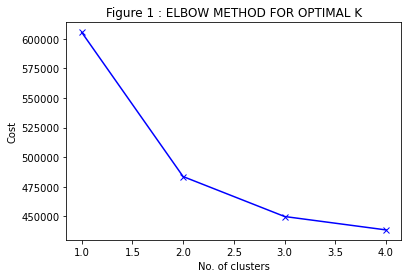

Based on the k-modes result, two subsets were formed. From the heatmaps for both the subsets in Figure 2 and Figure 3, it can be inferred that the multicollinearity effects remain almost similar in both subsets. The vaccine and immunization variables are closely related to each other. Additionally, the wealth index is highly correlated with the highest education level of the mother, place of residence and presence of electricity in the household.

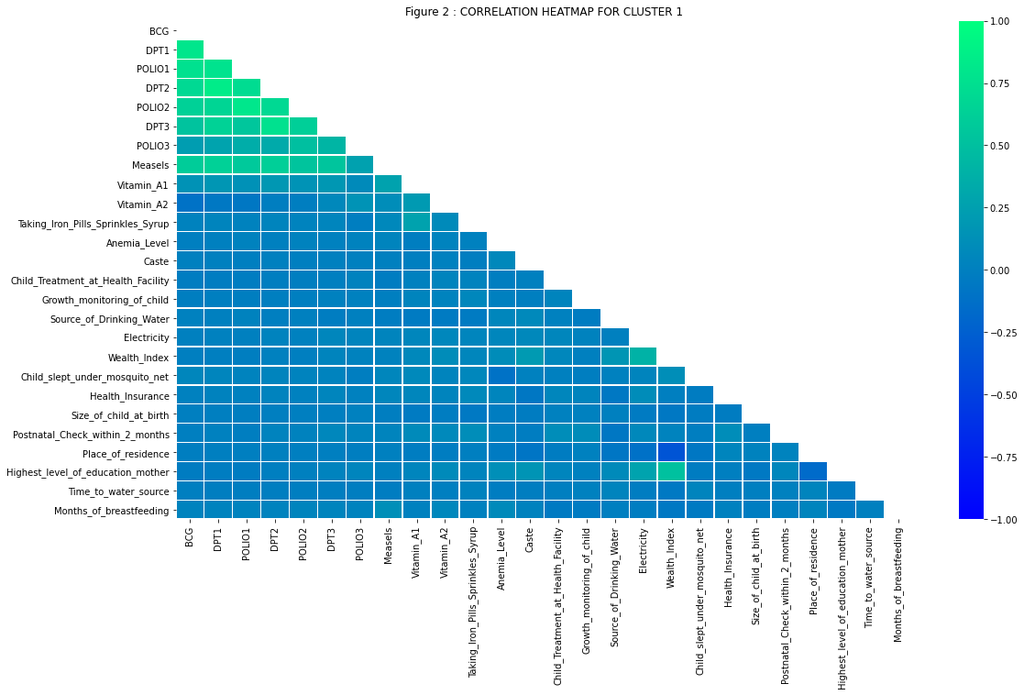

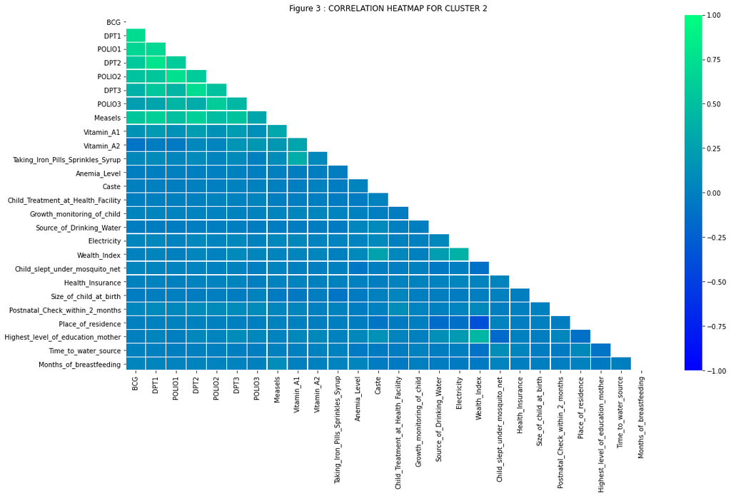

From Figure 4 and 5, it can be observed that the lower caste individuals (ST and SC) have higher proportions in the lower economic status, when compared to the richer and richest categories. This indicates that caste as a factor of wealth index is a national phenomenon.

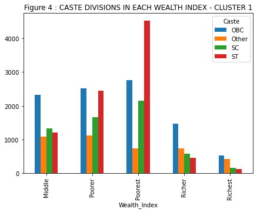

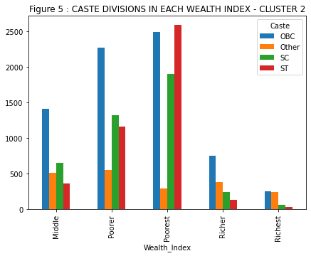

From Figure 6 and 7, it can be inferred that most people living in cluster 2 states happen to not be covered by health insurance, when compared to the other states.

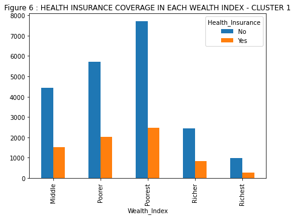

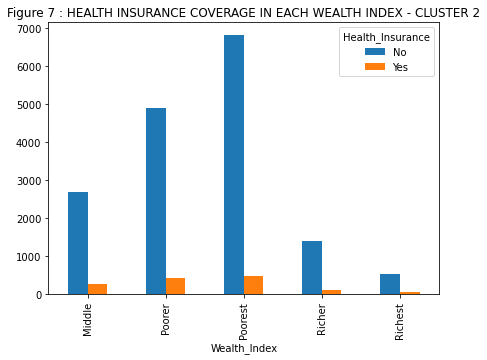

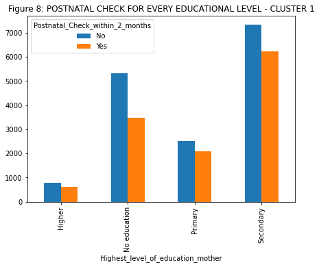

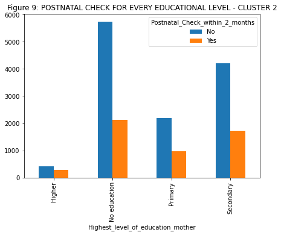

From Figure 10 and 11, it can be inferred that the relation between mothers visiting a health facility to monitor the growth of a child given the child’s size at birth remains almost similar.

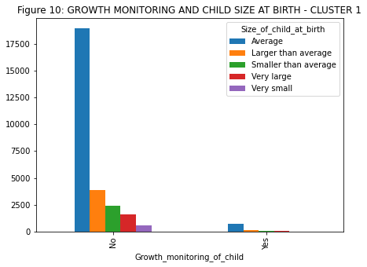

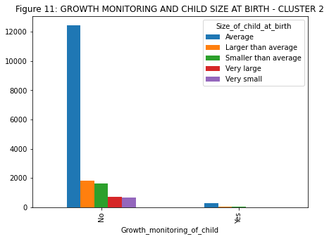

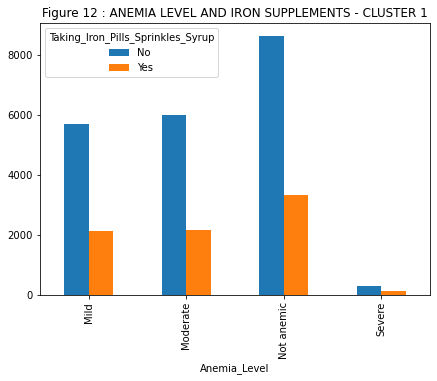

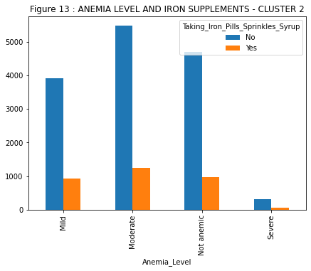

From Figure 14 and 15, it can be observed that there is a higher proportion of people in cluster 2 using tube-wells or boreholes as the main source of drinking water, as compared to the other states.

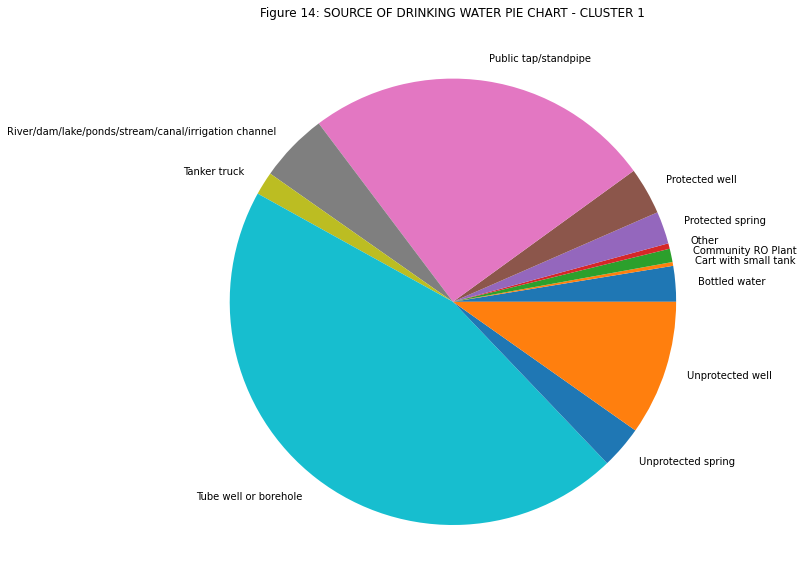

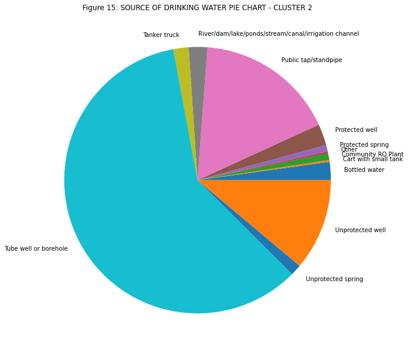

Each of these clusters were split into training and testing in a 75:25 ratio. The data was scaled using Standard Scaler, and then passed through the machine learning pipeline. The linear regression model was the best model on the training data for both the clusters. Permutation importance of every feature was then implemented. Below are the results of most important factors that explain BMI in each cluster.

Table 1: Variable Importance for Cluster 1 (Other states)

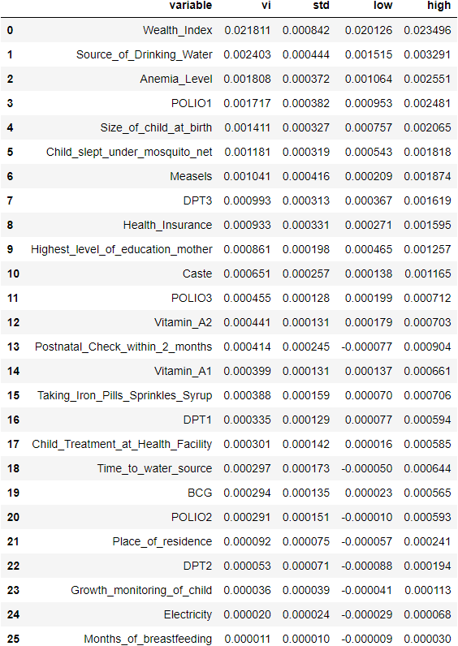

Table 2: Variable Importance for Cluster 2 (Gujarat, Madhya Pradesh, Nagaland, Rajasthan, Uttar Pradesh and Uttrakhand)

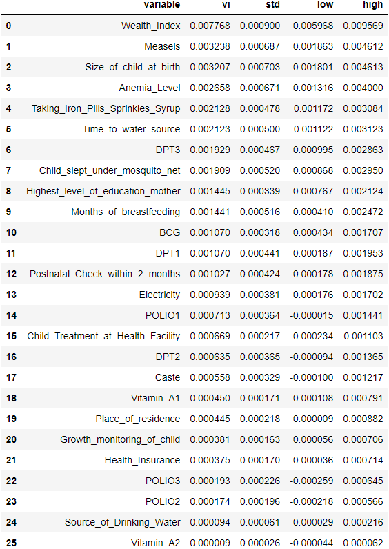

However, poor evaluation metrics for each of the models are observed. R-squared values of 0.018 and 0.01 were observed for the models. These imply that the features do not explain BMI values significantly. Following are some of the possible reasons for poor fit of the data.

- BMI measurement: While there has been clear information about feature variables in the official recode manual for the NFHS-4 survey, the only information provided for BMI is that it has been ordered according to WHO standards. Lack of clear information about the WHO standards specification, and use of standard deviations of each child’s BMI might not have been an appropriate target variable. More information about the BMI measurement, and finding raw values for the same may suit this project better.
- Measurement Error and Survey Data Collection: With survey data, there is always a high risk of measurement error in the data. Mothers who were interviewed may have provided improper results either for fear of revealing true information, or for maintaining their privacy. Additionally, the data might not be reliable as the results are based on the mother’s answers and is not clinically approved data. Furthermore, there might be inherent errors due to construction of the survey questions and response codes. For example, the vaccine questions are coded as either vaccine not given, the vaccine date marked properly in the health card, mother reporting that the child received the vaccine but not present in health card, or vaccination marked in health card without the date. This does not include an option of whether the child is eligible to receive each vaccine status yet. Such survey construction could have possibly impacted the fit of the models. Moreover, the three shots of DPT and POLIO could have been merged to reduce mulicollinearity. However, survey sampling error is not suspected as the households were chosen to be nationally representative.
- Other Models: Other models could have been used for both the unsupervised and supervised models. This model only used a handful of the responses present in the survey. Using more responses and performing dimensionality reduction with principal component analysis may have produced more ‘information-important’ features that could have potentially explained BMI levels better. In the supervised learning methods pipeline, other models such as Lasso regression may have produced better results, as it is useful for feature selection. Moreover, the lack of hyper-parameter tuning for the random forest model may have potentially resulted in poor evaluation metrics.

### **CONCLUSION:**

This project aimed at analyzing the effects of various factors on a child’s BMI index, which would help policy-makers and governments identify main determinants of child malnutrition in India. K-modes clustering was performed to account for states that have similar trends. The important factors for each cluster vary to an extent, indicating that an over-arching national policy may not solve the issue, and state-wise factors must be accounted for. However, the poor evaluation metrics observed imply that the underlying data cannot be used for accurate analysis. Corrections for the possible sources of errors listed above need to be explored, along with further analysis of data to ensure that better evaluation metrics are observed and credible results are obtained for identifying the main determinants of child malnutrition are observed.

### **REFERENCES:**

- UNICEF Canada, n.d.  
  https://www.unicef.ca/en/malnutrition
- Bakwin-Kandala et al., 2011  
  https://bmcpublichealth.biomedcentral.com/articles/10.1186/1471-2458-11-261#Sec10
- WH0 International, 2021  
  https://www.who.int/news-room/fact-sheets/detail/malnutrition
- Economic Times, 2019  
  https://economictimes.indiatimes.com/news/politics-and-nation/malnutrition-behind-69-per-cent-deaths-among-children-below-5-years-in-india-unicef-report/articleshow/71618288.cms
- N. Anilkumar et al., 2017  
  Characteristics and causes of malnutrition across Indian States: A cluster analysis based on Indian demographic and Health Survey Data, International Conference on Advances in Computing, Communications and Informatics (ICCACCI)
- S. Khare et al., 2017  
  Investigation of Nutritional Status of Children based on Machine Learning Techniques using Indian Demographic and Health Survey Data, Procedia Computer Science
- S. Kar et al., 2021  
  Prediction of Child Malnutrition using Machine Learning, 10th International Conference on Internet of Everything, Microwave Engineering, Communication and Networks
- DownToEarth, 2021  
  https://www.downtoearth.org.in/blog/health/child-malnutrition-in-india-a-systemic-failure-76507
- DW, 2017  
  https://www.dw.com/en/indias-caste-system-weakened-but-still-influential/a-39718124
- WHO International, n.d.  
  https://www.who.int/activities/raising-the-importance-of-postnatal-care
- Pew Research Center, 2021  
  https://www.pewresearch.org/fact-tank/2021/12/13/key-facts-about-the-religiously-and-demographically-diverse-states-of-india/
- Bonthu, 2021  
  https://www.analyticsvidhya.com/blog/2021/06/kmodes-clustering-algorithm-for-categorical-data/

### **DATA SOURCE:**

The Demographic and Health Survey Program, USAID  
https://dhsprogram.com/methodology/survey/survey-display-355.cfm

#### **ADDITIONAL NOTES:**

The report alone (without figures, tables and references) is 4.5 pages, single-space and 11pt font size.